# Assignment 2: Boston Data

# Objective

This project aims to build a logistic regression model to classify crime levels in the Boston dataset. By analyzing socio-economic and housing-related factors, we will predict whether crime is high or low. After performing exploratory data analysis (EDA), we will fit the model and evaluate its performance using a confusion matrix and accuracy score. Finally, we will interpret the results to understand the key factors influencing crime rates.

# Data Import

```r
library(MASS)

data(Boston)

boston <- Boston[,c(2:8,10)]

set.seed(138006)
thr <- runif(1, min=0.2, max = 0.35)
thr
```

```
## [1] 0.3245115
```

```r
boston$crimclass <- ifelse(Boston$crim < thr, "Low", "High")
```

# Data Cleaning & Transforming

## Checking Column Names

```r
colnames(Boston)
```

```
##  [1] "crim"    "zn"      "indus"   "chas"    "nox"     "rm"      "age"
##  [8] "dis"     "rad"     "tax"     "ptratio" "black"   "lstat"   "medv"
```

When we look at the column names of the data, we can see there is no uppercase or blank characters. So we don’t have to clean the colnames.

## Data Cleaning

```r
cat("Number of NA's:", sum(is.na(Boston)), "\n")
```

```
## Number of NA's: 0
```

The number of NA’s is equal to zero. So we don’t have to clean the NA values form data.

## Glimpse and Summary

```r
library(tidyverse)
glimpse(Boston)
```

```
## Rows: 506
## Columns: 14
## $ crim    <dbl> 0.00632, 0.02731, 0.02729, 0.03237, 0.06905, 0.02985, 0.08829,…
## $ zn      <dbl> 18.0, 0.0, 0.0, 0.0, 0.0, 0.0, 12.5, 12.5, 12.5, 12.5, 12.5, 1…
## $ indus   <dbl> 2.31, 7.07, 7.07, 2.18, 2.18, 2.18, 7.87, 7.87, 7.87, 7.87, 7.…
## $ chas    <int> 0, 0, 0, 0, 0, 0, 0, 0, 0, 0, 0, 0, 0, 0, 0, 0, 0, 0, 0, 0, 0,…
## $ nox     <dbl> 0.538, 0.469, 0.469, 0.458, 0.458, 0.458, 0.524, 0.524, 0.524,…
## $ rm      <dbl> 6.575, 6.421, 7.185, 6.998, 7.147, 6.430, 6.012, 6.172, 5.631,…
## $ age     <dbl> 65.2, 78.9, 61.1, 45.8, 54.2, 58.7, 66.6, 96.1, 100.0, 85.9, 9…
## $ dis     <dbl> 4.0900, 4.9671, 4.9671, 6.0622, 6.0622, 6.0622, 5.5605, 5.9505…
## $ rad     <int> 1, 2, 2, 3, 3, 3, 5, 5, 5, 5, 5, 5, 5, 4, 4, 4, 4, 4, 4, 4, 4,…
## $ tax     <dbl> 296, 242, 242, 222, 222, 222, 311, 311, 311, 311, 311, 311, 31…
## $ ptratio <dbl> 15.3, 17.8, 17.8, 18.7, 18.7, 18.7, 15.2, 15.2, 15.2, 15.2, 15…
## $ black   <dbl> 396.90, 396.90, 392.83, 394.63, 396.90, 394.12, 395.60, 396.90…
## $ lstat   <dbl> 4.98, 9.14, 4.03, 2.94, 5.33, 5.21, 12.43, 19.15, 29.93, 17.10…
## $ medv    <dbl> 24.0, 21.6, 34.7, 33.4, 36.2, 28.7, 22.9, 27.1, 16.5, 18.9, 15…
```

From here we see that we have 506 observations. We have 14 columns which all have numberic values.

```r
summary(Boston)
```

```
##       crim                zn             indus            chas
##  Min.   : 0.00632   Min.   :  0.00   Min.   : 0.46   Min.   :0.00000
##  1st Qu.: 0.08205   1st Qu.:  0.00   1st Qu.: 5.19   1st Qu.:0.00000
##  Median : 0.25651   Median :  0.00   Median : 9.69   Median :0.00000
##  Mean   : 3.61352   Mean   : 11.36   Mean   :11.14   Mean   :0.06917
##  3rd Qu.: 3.67708   3rd Qu.: 12.50   3rd Qu.:18.10   3rd Qu.:0.00000
##  Max.   :88.97620   Max.   :100.00   Max.   :27.74   Max.   :1.00000
##       nox               rm             age              dis
##  Min.   :0.3850   Min.   :3.561   Min.   :  2.90   Min.   : 1.130
##  1st Qu.:0.4490   1st Qu.:5.886   1st Qu.: 45.02   1st Qu.: 2.100
##  Median :0.5380   Median :6.208   Median : 77.50   Median : 3.207
##  Mean   :0.5547   Mean   :6.285   Mean   : 68.57   Mean   : 3.795
##  3rd Qu.:0.6240   3rd Qu.:6.623   3rd Qu.: 94.08   3rd Qu.: 5.188
##  Max.   :0.8710   Max.   :8.780   Max.   :100.00   Max.   :12.127
##       rad              tax           ptratio          black
##  Min.   : 1.000   Min.   :187.0   Min.   :12.60   Min.   :  0.32
##  1st Qu.: 4.000   1st Qu.:279.0   1st Qu.:17.40   1st Qu.:375.38
##  Median : 5.000   Median :330.0   Median :19.05   Median :391.44
##  Mean   : 9.549   Mean   :408.2   Mean   :18.46   Mean   :356.67
##  3rd Qu.:24.000   3rd Qu.:666.0   3rd Qu.:20.20   3rd Qu.:396.23
##  Max.   :24.000   Max.   :711.0   Max.   :22.00   Max.   :396.90
##      lstat            medv
##  Min.   : 1.73   Min.   : 5.00
##  1st Qu.: 6.95   1st Qu.:17.02
##  Median :11.36   Median :21.20
##  Mean   :12.65   Mean   :22.53
##  3rd Qu.:16.95   3rd Qu.:25.00
##  Max.   :37.97   Max.   :50.00
```

We see that (`chas`) has so many observations that equal to zero. When we look at the 1st and 3rd quartile values of (`chas`) we can say that at least 75% of the observations are equal to zero. When we look at the median (0) and mean (11.36) values of (`zn`) we see a noticeable difference, with the mean being much higher than the median. This indicates that the distribution is right-skewed. Also the we see that 1st quartile and median values of (`zn`) is equal to zero, which means that 50% of the observations are equal to zero.

# A Visual Summary: ggpairs

```r
library(GGally)
```

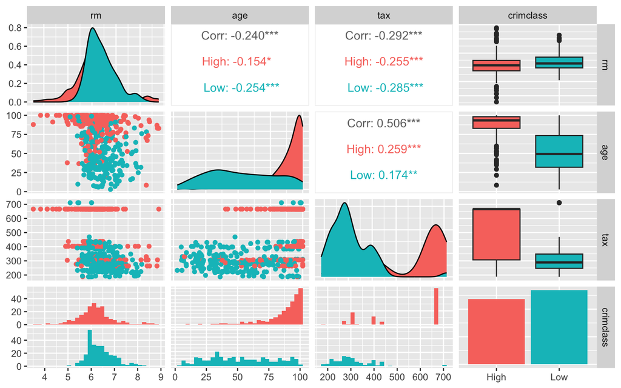

```r
ggpairs(boston[, c("rm", "age", "tax", "crimclass")], aes(color = crimclass))
```

```r
crime_table <- table(boston$crimclass)
print(crime_table)
```

```
##
## High  Low
##  237  269
```

It shows that there are 237 entries in the “High” crime class and 269 in the “Low” crime class. This indicates a fairly balanced distribution, with slightly more cases in the “Low” category.

# Crimclass Factor Transformation

```r
class(boston$crimclass)
```

```
## [1] "character"
```

First we check the class of (`crimclass`) variable and we see that its a character. So we need to transform it to factor to later use.

```r
boston$crimclass <- as.factor(boston$crimclass)

class(boston$crimclass)
```

```
## [1] "factor"
```

After the transformation we check the class of (`crimclass`) and now we can see that it is a factor now.

# Creating the Logistic Regression Model

```r
fit.logit <- glm(crimclass ~ ., data = boston, family = binomial)

summary(fit.logit)
```

```
##
## Call:
## glm(formula = crimclass ~ ., family = binomial, data = boston)
##
## Coefficients:
##               Estimate Std. Error z value Pr(>|z|)
## (Intercept)  34.249359   4.704917   7.279 3.35e-13 ***
## zn            0.090756   0.031377   2.892  0.00382 **
## indus         0.125634   0.046208   2.719  0.00655 **
## chas         -1.927633   0.662350  -2.910  0.00361 **
## nox         -41.922734   6.297732  -6.657 2.80e-11 ***
## rm           -1.034008   0.263266  -3.928 8.58e-05 ***
## age          -0.017283   0.008828  -1.958  0.05026 .
## dis          -0.733090   0.186724  -3.926 8.64e-05 ***
## tax          -0.006657   0.001686  -3.948 7.87e-05 ***
## ---
## Signif. codes:  0 '***' 0.001 '**' 0.01 '*' 0.05 '.' 0.1 ' ' 1
##
## (Dispersion parameter for binomial family taken to be 1)
##
##     Null deviance: 699.44  on 505  degrees of freedom
## Residual deviance: 263.49  on 497  degrees of freedom
## AIC: 281.49
##
## Number of Fisher Scoring iterations: 8
```

- According to the logistic regression output, several variables significantly affect crime classification.
- Notably, higher nitrogen oxide concentration (`nox`) is a strong predictor of higher crime levels.
- Similarly, variables like room count (`rm`), property tax (`tax`), and distance from employment (`dis`) are all positively associated with crime, which may suggest complex socio-economic dynamics.
- Conversely, residential zoning (`zn`) and industrial proportion (`indus`) are negatively associated with crime, indicating that more organized residential or industrial planning might correlate with safer areas.